# STA208 Final Project

## Predicting Marine Organism Conservation Status

**Author:** Evan Batzer

**Date:** 6/2/2020

### 0. Background

Biodiversity loss is a major focus of environmental management in the 21st century -- extinctions of plant and animal species is estimated to be 10 - 100 times greater than in the past 10 million years, largely as a function of human activity.

Several organizations have attempted to provide global-level databases to help monitor and predict biodiversity loss. Chief among these is the **IUCN**, the International Union for the Conservation of Nature, which publishes a continually updating list of species known as the *Red List*.

[figure not shown]

The *Red List* is established as a useful tool for conservation decision-making, but is difficult to maintain. There are estimated to be roughly 8.7 Million species on the planet, each of which must be assessed by a panel of experts to be included on the *Red List*.

Species are given a conservation designation ranging from "Least Concern" to "Extinct".

[figure not shown]

However, species given conservation designations on the *Red List* often share similar characteristics -- size, reproductive capacity, human use for agriculture, etc. These features may be effective classifiers of species with known conservation designations and may help speed the process of generating and updating IUCN databases.

**Core Question:** How well can conservation status be classified by species characteristics?

### 1. Assembling Dataset

#### 1.1 Querying FishBase API

FishBase is a global database containing information on the characteristics and distribution of roughly 34,000 fish species. These characteristics are thought to be good predictors of species IUCN status. Large, slow-growing species, for example, may be more likely to go extinct than smaller, faster-growing species with limited commercial value.

Data is open access and generally well-documented, but provided at several levels of organization. Because IUCN categorization is made at the species level, meaningful features must be extracted, cleaned, and aggregated at an appropriate scale.

```python
# All available species
taxaTable = extract_fishbase("taxa")

# General species characteristics
speciesTable = extract_fishbase("species")

# Species ecology (habitat type, prey, etc.)
ecologyTable = extract_fishbase("ecology")

# Ecosystem characteristics
ecosystemTable = extract_fishbase("ecosystem")

# Maturity / reproduction
reproTable = extract_fishbase("maturity")
```

```
Table ''taxa' - Returned 34342 rows of 14 features
Table ''species' - Returned 34342 rows of 102 features
Table ''ecology' - Returned 11897 rows of 142 features
Table ''ecosystem' - Returned 151869 rows of 47 features
Table ''maturity' - Returned 8733 rows of 35 features
```

```python
features = taxa_subset.join([spec_subset, eco_subset, repro_subset, ecosys_full])
features.head()
```

| SpecCode | Genus | Species | Family | Order | Class | Vulnerability | Length | Weight | GameFish | Imp_ | ... | brackish | tropical | subtropical | polar | temperate | boreal | Area | AverageDepth | TempSurface | TempDepth |
| --- | --- | --- | --- | --- | --- | --- | --- | --- | --- | --- | --- | --- | --- | --- | --- | --- | --- | --- | --- | --- | --- |
| 48039 | Abyssocottus | elochini | Abyssocottidae | Scorpaeniformes | Actinopterygii | 40.29 | NaN | NaN | 0.0 | 0.0 | ... | NaN | NaN | NaN | NaN | NaN | NaN | NaN | NaN | NaN | NaN |
| 48040 | Abyssocottus | gibbosus | Abyssocottidae | Scorpaeniformes | Actinopterygii | 35.49 | 14.0 | NaN | 0.0 | 0.0 | ... | NaN | NaN | NaN | NaN | NaN | NaN | NaN | NaN | NaN | NaN |
| 47208 | Abyssocottus | korotneffi | Abyssocottidae | Scorpaeniformes | Actinopterygii | 32.97 | 12.6 | NaN | 0.0 | 0.0 | ... | NaN | NaN | NaN | NaN | NaN | NaN | NaN | NaN | NaN | NaN |
| 48048 | Asprocottus | abyssalis | Abyssocottidae | Scorpaeniformes | Actinopterygii | 38.21 | NaN | NaN | 0.0 | 0.0 | ... | NaN | NaN | NaN | NaN | NaN | NaN | NaN | NaN | NaN | NaN |
| 48049 | Asprocottus | herzensteini | Abyssocottidae | Scorpaeniformes | Actinopterygii | 33.02 | 11.5 | NaN | 0.0 | 0.0 | ... | NaN | NaN | NaN | NaN | NaN | NaN | NaN | NaN | NaN | NaN |

5 rows × 74 columns

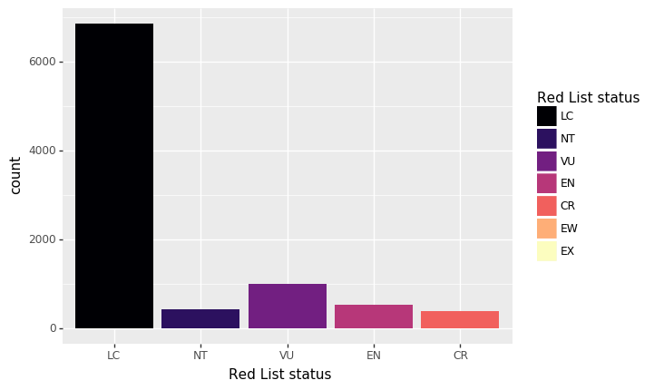

```python
(ggplot(data_labelled,
       aes(x = 'Red List status',
          fill = 'Red List status')) +
 geom_bar() +
scale_fill_cmap_d("magma"))
```

### 2. Binary Classification -- "Least Concern" vs. Others

The simplest way to look at this data is through a binary classification between the "Least Concern" class and all others that reflect some degree of vulnerability to extinction. This approach is common in published studies that have examined this problem.

```python
scaler = StandardScaler()

# Standardizing quantitative columns
quantcols = ['Length', 'Weight','DietTLu','Area','AverageDepth','TempSurface','TempDepth', 'Age_Maturity', 'Length_Maturity']
quant_std = pd.DataFrame(scaler.fit_transform(features_bin[quantcols]),
                           columns = quantcols)

# Standardized dataset (lots of NA's!)
features_std = pd.concat([quant_std, features_bin.drop(quantcols, axis = 1)], axis = 1)
features_std.head()
```

|  | Length | Weight | DietTLu | Area | AverageDepth | TempSurface | TempDepth | Age_Maturity | Length_Maturity | GameFish | ... | Lakes | Cave | freshwater | saltwater | brackish | tropical | subtropical | polar | temperate | boreal |
| --- | --- | --- | --- | --- | --- | --- | --- | --- | --- | --- | --- | --- | --- | --- | --- | --- | --- | --- | --- | --- | --- |
| 0 | -0.139854 | NaN | -0.455351 | NaN | NaN | NaN | NaN | NaN | NaN | 0.0 | ... | 0.0 | 0.0 | 1.0 | 1.0 | 0.0 | 1.0 | 0.0 | 0.0 | 0.0 | 0.0 |
| 1 | 0.017366 | NaN | -0.455351 | NaN | NaN | NaN | NaN | NaN | NaN | 0.0 | ... | 0.0 | 0.0 | 0.0 | 0.0 | 0.0 | 1.0 | 0.0 | 0.0 | 0.0 | 0.0 |
| 2 | 0.226993 | NaN | -0.455351 | 1.052117 | 0.489980 | 0.009435 | 0.154410 | NaN | NaN | 0.0 | ... | 0.0 | 0.0 | 1.0 | 0.0 | 0.0 | 1.0 | 0.0 | 0.0 | 0.0 | 0.0 |
| 3 | NaN | NaN | NaN | NaN | NaN | NaN | NaN | NaN | NaN | 0.0 | ... | NaN | NaN | NaN | NaN | NaN | NaN | NaN | NaN | NaN | NaN |
| 4 | 0.314337 | NaN | -0.455351 | -0.493121 | -0.090207 | 0.308765 | 0.197353 | NaN | NaN | 0.0 | ... | 0.0 | 0.0 | 1.0 | 0.0 | 0.0 | 1.0 | 0.0 | 0.0 | 0.0 | 0.0 |

5 rows × 66 columns

```python
# Initializing cross-validation search
random_search = RandomizedSearchCV(xgb_classifier, param_distributions=params,
                                   n_iter=param_comb, scoring='accuracy', n_jobs=4,
                                   cv=skf.split(x_full,y_full), verbose=3, random_state=0)

# Running randomized CV search
random_search.fit(x_full, y_full)

random_search.best_score_
```

```
Fitting 5 folds for each of 25 candidates, totalling 125 fits
```

```
[Parallel(n_jobs=4)]: Using backend LokyBackend with 4 concurrent workers.
[Parallel(n_jobs=4)]: Done  24 tasks      | elapsed:  2.3min
[Parallel(n_jobs=4)]: Done 125 out of 125 | elapsed: 15.5min finished
```

```
0.7748572963653969
```

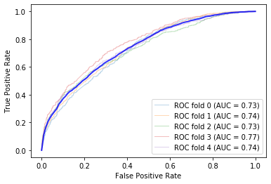

```python
fig, ax = plt.subplots()
for i, (train, test) in enumerate(skf.split(x_full,y_full)):
    bestmod_1.fit(x_full[train], y_full[train])
    viz = plot_roc_curve(bestmod_1, x_full[test], y_full[test],
                         name='ROC fold {}'.format(i),
                         alpha=0.3, lw=1, ax=ax)
    interp_tpr = np.interp(mean_fpr, viz.fpr, viz.tpr)
    interp_tpr[0] = 0.0
    tprs.append(interp_tpr)
    aucs.append(viz.roc_auc)

mean_tpr = np.mean(tprs, axis=0)
mean_tpr[-1] = 1.0
mean_auc = auc(mean_fpr, mean_tpr)
std_auc = np.std(aucs)
ax.plot(mean_fpr, mean_tpr, color='b',
        label=r'Mean ROC (AUC = %0.2f $\pm$ %0.2f)' % (mean_auc, std_auc),
        lw=2, alpha=.8)
```

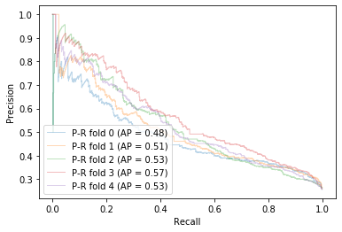

```python
prec = []
rec = []
mean_prec = np.linspace(0, 1, 100)
fig, ax = plt.subplots()
for i, (train, test) in enumerate(skf.split(x_full,y_full)):
    bestmod_1.fit(x_full[train], y_full[train])
    viz = plot_precision_recall_curve(bestmod_1, x_full[test], y_full[test],
                         name='P-R fold {}'.format(i),
                         alpha=0.3, lw=1, ax=ax)
    interp_tpr = np.interp(mean_prec, viz.precision, viz.recall)
    interp_tpr[0] = 0.0
    tprs.append(interp_tpr)
```

### 3. Imputing Missing Features

Ideally, imputation could be constructed using phylogenetic information from different species -- the genetic relationships that describe how similar species are to one another on an evolutionary scale. Given the scope of this dataset, however, a full *time-calibrated phylogeny of all fish species* is not available.

However, many features are predictive of one another. Larger fish, for example, are likely to have longer times to maturity and slower reproductive rates. Approches like K-Nearest Neighbors or Random Forest based imputation are known to be [effective imputers for species trait data](https://besjournals.onlinelibrary.wiley.com/doi/10.1111/2041-210X.12232) in certain circumstances.

```python
# imputer = IterativeImputer(estimator = KNeighborsRegressor(n_neighbors=5),
#                            add_indicator=True)

# data_imputed = imputer.fit_transform(features_std)
```

```python
# imputed_cols = features_std.columns.append(features_std.columns[features_std.isnull().any()] + "Missing")
# data_imputed = pd.DataFrame(data_imputed, columns = imputed_cols)
# data_imputed.to_csv("data/imputed_features.csv")
```

```python
pd.read_csv('data/imputed_features.csv').head()
```

|  | Unnamed: 0 | Length | Weight | DietTLu | Area | AverageDepth | TempSurface | TempDepth | Age_Maturity | Length_Maturity | ... | LakesMissing | CaveMissing | freshwaterMissing | saltwaterMissing | brackishMissing | tropicalMissing | subtropicalMissing | polarMissing | temperateMissing | borealMissing |
| --- | --- | --- | --- | --- | --- | --- | --- | --- | --- | --- | --- | --- | --- | --- | --- | --- | --- | --- | --- | --- | --- |
| 0 | 0 | -0.139854 | -0.068625 | -0.455351 | 0.492794 | 0.420358 | 0.803895 | 1.040876 | -0.638508 | -0.527541 | ... | 0.0 | 0.0 | 0.0 | 0.0 | 0.0 | 0.0 | 0.0 | 0.0 | 0.0 | 0.0 |
| 1 | 1 | 0.017366 | -0.068981 | -0.455351 | -0.726752 | 0.188283 | 0.107216 | 0.042759 | -0.638293 | -0.462761 | ... | 0.0 | 0.0 | 0.0 | 0.0 | 0.0 | 0.0 | 0.0 | 0.0 | 0.0 | 0.0 |
| 2 | 2 | 0.226993 | -0.066908 | -0.455351 | 1.052117 | 0.489980 | 0.009435 | 0.154410 | -0.418321 | -0.335671 | ... | 0.0 | 0.0 | 0.0 | 0.0 | 0.0 | 0.0 | 0.0 | 0.0 | 0.0 | 0.0 |
| 3 | 3 | -0.509042 | -0.069449 | -0.455351 | -1.291229 | -4.194679 | -0.469493 | -1.512993 | -0.434417 | -0.693165 | ... | 1.0 | 1.0 | 1.0 | 1.0 | 1.0 | 1.0 | 1.0 | 1.0 | 1.0 | 1.0 |
| 4 | 4 | 0.314337 | -0.065984 | -0.455351 | -0.493121 | -0.090207 | 0.308765 | 0.197353 | -0.638508 | -0.367560 | ... | 0.0 | 0.0 | 0.0 | 0.0 | 0.0 | 0.0 | 0.0 | 0.0 | 0.0 | 0.0 |

5 rows × 105 columns

### 4. Binary Classification - Imputed Data

```python
x_full = pd.read_csv('data/imputed_features.csv') # Standardized predictors
y_full = data_labelled["Red List status"] == "LC" * 1 # Classes - whether "Least Concern" or not
y_full = 1 - y_full

# Initializing cross-validation search
random_search = RandomizedSearchCV(xgb_classifier, param_distributions=params,
                                   n_iter=param_comb, scoring='accuracy', n_jobs=4,
                                   cv=skf.split(x_full,y_full), verbose=3, random_state=0)

# Running randomized CV search
random_search.fit(x_full, y_full)

random_search.best_score_
```

```
Fitting 5 folds for each of 25 candidates, totalling 125 fits
```

```
[Parallel(n_jobs=4)]: Using backend LokyBackend with 4 concurrent workers.
[Parallel(n_jobs=4)]: Done  24 tasks      | elapsed:  2.7min
[Parallel(n_jobs=4)]: Done 125 out of 125 | elapsed: 21.1min finished
```

```
0.783114033016083
```

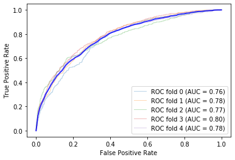

```python
fig, ax = plt.subplots()
for i, (train, test) in enumerate(skf.split(x_full,y_full)):
    bestmod_2.fit(x_full[train], y_full[train])
    viz = plot_roc_curve(bestmod_2, x_full[test], y_full[test],
                         name='ROC fold {}'.format(i),
                         alpha=0.3, lw=1, ax=ax)
    interp_tpr = np.interp(mean_fpr, viz.fpr, viz.tpr)
    interp_tpr[0] = 0.0
    tprs.append(interp_tpr)
    aucs.append(viz.roc_auc)
mean_tpr = np.mean(tprs, axis=0)
mean_tpr[-1] = 1.0
mean_auc = auc(mean_fpr, mean_tpr)
std_auc = np.std(aucs)

ax.plot(mean_fpr, mean_tpr, color='b',
        label=r'Mean ROC (AUC = %0.2f $\pm$ %0.2f)' % (mean_auc, std_auc),
        lw=2, alpha=.8)
```

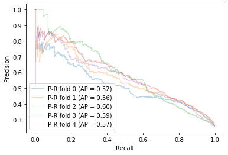

```python
prec = []
rec = []
mean_prec = np.linspace(0, 1, 100)
fig, ax = plt.subplots()
for i, (train, test) in enumerate(skf.split(x_full,y_full)):
    bestmod_2.fit(x_full[train], y_full[train])
    viz = plot_precision_recall_curve(bestmod_2, x_full[test], y_full[test],
                         name='P-R fold {}'.format(i),
                         alpha=0.3, lw=1, ax=ax)
    interp_tpr = np.interp(mean_prec, viz.precision, viz.recall)
    interp_tpr[0] = 0.0
    tprs.append(interp_tpr)
```

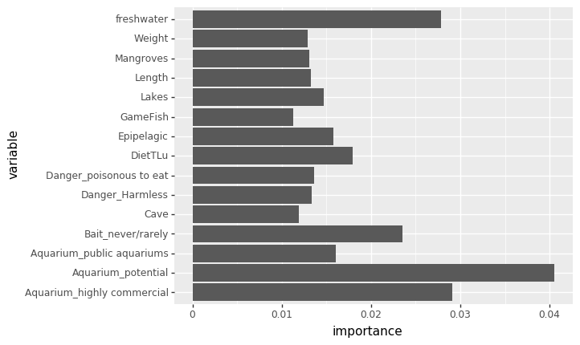

```python
imputed_cols = features_std.columns.append(features_std.columns[features_std.isnull().any()] + "Missing")
var_imp = pd.concat([pd.Series(bestmod_2.feature_importances_),
             pd.Series(imputed_cols)],axis = 1)
var_imp.columns=["importance", "variable"]
var_imp.sort_values('importance')

(ggplot(aes(y = 'importance',
            x = 'variable'),
       (var_imp.iloc[:-40,].sort_values('importance', ascending=False))[:15]) +
 geom_bar(stat = "identity") +
 coord_flip())
```

### 5. Ordinal Classification - Conservation Status as a pseudo-numeric scale

The key next step in this project is to adapt an ordinal classification method to this data. Several approaches seem possible.

- One approach is to adapt our learning objective to a binary classifier, like SVM, by decomposing ordinal classes into a series of sequential tasks:
- $P(y_i = LC) = 1 - P(y_i > LC)$
- $P(y_i = NT) = P(y_i > LC) - P(y_i > NT)$

$\dots$

- $P(y_i = CR) = P(y_i > CR)$

Assigned classes can be generated by the maximum probability for each label.

- Other options include using existing ordinal regression libraries, such as `mord`, that include implementations of different ordinal regression algorithms.